# Data Exploration Project

Brian Thomas

5/15/2022

## Intro

The College Scorecard is a public-facing website that contains important information about colleges, including how much its graduates earn. This information has traditionally been very difficult to find. The College Scorecard that was released at the start of September 2015 shows data from colleges that predominantly grant Bachelors degrees. In this exploration project I will be looking at whether or not the release of the College Scorecard has been effective in shifting student interest in high-earning colleges relative to low-earning colleges.

```r
# Filter the file data for the bachelor degrees and omit all the NA values if any.
final_data <- read_csv('~finaldata.csv', show_col_types = FALSE)
final_data <- final_data %>%
  drop_na()
final_data <- final_data[ , colSums(is.na(final_data)) < nrow(final_data)]
clean_df <- final_data %>%
  filter(preddeg == 3, na.rm=TRUE)
```

# Analysis

Since our College Scorecard data looks at the colleges predominantly from the end of the 2015 year, I’ve decided to do some searching and according to the U.S bureau of labor statistics, at the start of the year 2016, the median income of workers with a Bachelors degree in the U.S. was $1,155. Which in turn gives us a Median Annual Salary of $60,060. This will become the split value between the high income and low income college groups.

Use ifelse() function to set the split, where ‘1’ is high income and ‘0’ is low income by the $60,060 median annual salary.

```r
clean_df$medianEarning <- ifelse(clean_df$`md_earn_wne_p10-reported-earnings` >= 60060, '1', '0')
```

Limit the size of the data set and get rid of the columns that we will not use

```r
clean_df <- clean_df %>%
  dplyr::select(unitid, instnm, monthorweek, preddeg, sat_avg, `md_earn_wne_p10-reported-earnings`, medianEarning, index, index_id) %>%
  mutate(date= as.Date(str_sub(monthorweek, 1,10))) %>%
  group_by(month = floor_date(date, "month"), medianEarning) %>%
  summarize(index_id = mean(index_id))
```

# Regression

Since the US college scorecard was launched on September 12, 2015. By using feols() and mutate() We will use this date to test whether there was an effect on the Google Trends data of median income, after the college scorecard was administered. The regression below is going to test whether there is an impact on Google Trends index on median income.

```r
final_data <- final_data %>%
  mutate(earning = `md_earn_wne_p10-reported-earnings` >= 60060, post_scorecard = monthorweek >=
           as.Date("2015-09-12"))
results <- feols(index_id ~ earning*post_scorecard, data=final_data)
etable(results, digits = 3)
```

```
##                                           results
## Dependent Var.:                          index_id
##
## (Intercept)                       3.84*** (0.002)
## earningTRUE                      0.448*** (0.008)
## post_scorecardTRUE                 -0.003 (0.005)
## earningTRUE x post_scorecardTRUE   -0.005 (0.018)
## ________________________________ ________________
## S.E. type                                     IID
## Observations                            1,209,654
## R2                                        0.00347
## Adj. R2                                   0.00347
## ---
## Signif. codes: 0 '***' 0.001 '**' 0.01 '*' 0.05 '.' 0.1 ' ' 1
```

# Visualization

We can use a visualization to show the impacts of Google Trends index between the high income and the low income colleges where 1 is high income and 0 is low income colleges

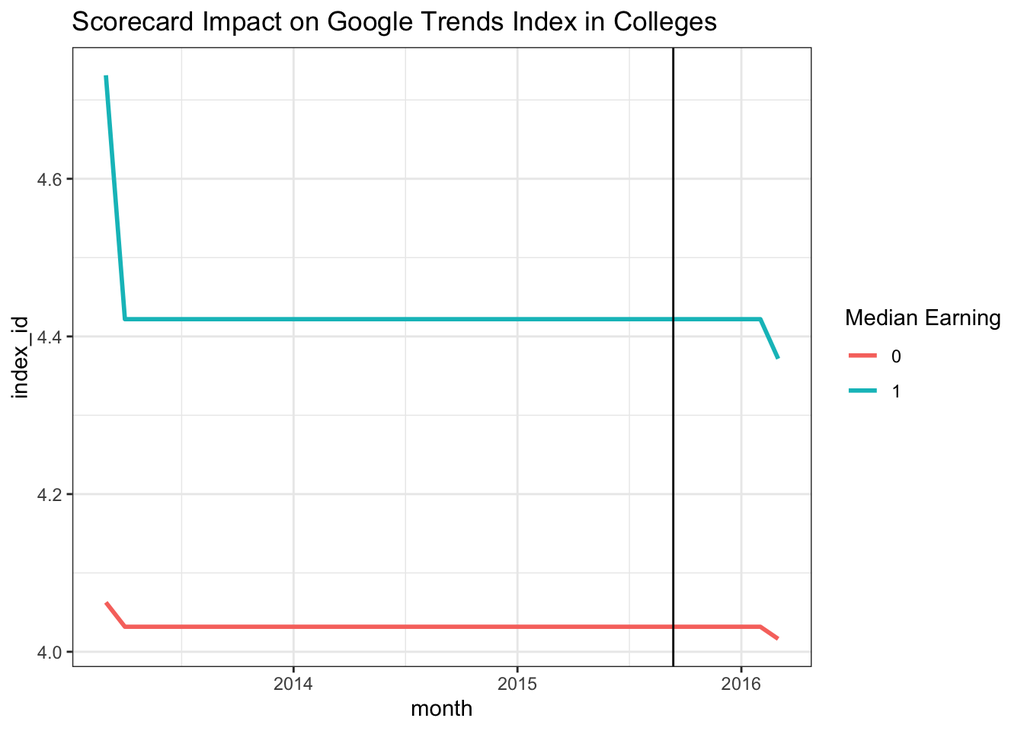

# Interpretation